# Submission HW2

# ISYE 6501 | Fall 22

- Ashish Dhiman | ashish.dhiman@gatech.edu
- Abhinav Arun | aarun60@gatech.edu
- Anshit Verma | averma373@gatech.edu

*Analysis Notes are marked with Red header: #Analysis

## Question 5.1

```bash
pwd
head -4 ./uscrime.txt
```

```
## /Users/anshitverma/Desktop/isye6501_aaa/hw4-1
## M    So  Ed  Po1 Po2 LF  M.F Pop NW  U1  U2  Wealth  Ineq    Prob    Time    Crime
## 15.1 1   9.1 5.8 5.6 0.51    95  33  30.1    0.108   4.1 3940    26.1    0.084602    26.2011 791
## 14.3 0   11.3    10.3    9.5 0.583   101.2   13  10.2    0.096   3.6 5570    19.4    0.029599    25.2999 1635
## 14.2 1   8.9 4.5 4.4 0.533   96.9    18  21.9    0.094   3.3 3180    25  0.083401    24.3006 578
```

### EDA of Crime Data

```r
crime_df = read.table("./uscrime.txt", sep="\t", header= TRUE)
dim(crime_df)
```

```
## [1] 47 16
```

3 states are missing in the data, we don’t know which.

#### Data and variable meaning:

Criminologists are interested in the effect of punishment regimes on crime rates. This has been studied using aggregate data on 47 states of the USA for 1960.

| Variable | Description |
| --- | --- |
| M | percentage of males aged 14–24 in total state population |
| So | indicator variable for a southern state |
| Ed | mean years of schooling of the population aged 25 years or over |
| Po1 | per capita expenditure on police protection in 1960 |
| Po2 | per capita expenditure on police protection in 1959 |
| LF | labour force participation rate of civilian urban males in the age-group 14-24 |
| M.F | number of males per 100 females |
| Pop | state population in 1960 in hundred thousands |
| NW | percentage of nonwhites in the population |
| U1 | unemployment rate of urban males 14–24 |
| U2 | unemployment rate of urban males 35–39 |
| Wealth | wealth: median value of transferable assets or family income |
| Ineq | income inequality: percentage of families earning below half the median income |
| Prob | probability of imprisonment: ratio of number of commitments to number of offenses |
| Time | average time in months served by offenders in state prisons before their first release |
| Crime | crime rate: number of offenses per 100,000 population in 1960 |

```r
summary(crime_df$Crime)
```

```
##    Min. 1st Qu.  Median    Mean 3rd Qu.    Max.
##   342.0   658.5   831.0   905.1  1057.5  1993.0
```

### Difference b/w Southern and Northern states

```r
aggregate(Pop ~ So, crime_df, sum)
```

| So | Pop |
| --- | --- |
| 0 | 1177 |
| 1 | 544 |

```r
south_split = aggregate(cbind(Crime,Ineq,M,M.F,U1,Time,NW,Ed) ~ So, crime_df, mean)
south_split
```

| So | Crime | Ineq | M | M.F | U1 | Time | NW | Ed |
| --- | --- | --- | --- | --- | --- | --- | --- | --- |
| 0 | 930.0000 | 17.30968 | 13.33548 | 98.96129 | 0.09767742 | 26.26139 | 4.506452 | 11.12258 |
| 1 | 856.8125 | 23.45000 | 14.86875 | 97.02500 | 0.09118750 | 27.24995 | 20.975000 | 9.48125 |

We see that Southern states in 1960s(on average):

- had <50% of non So population
- were more inequal
- had greater proportion of NW
- lower mean years of schooling

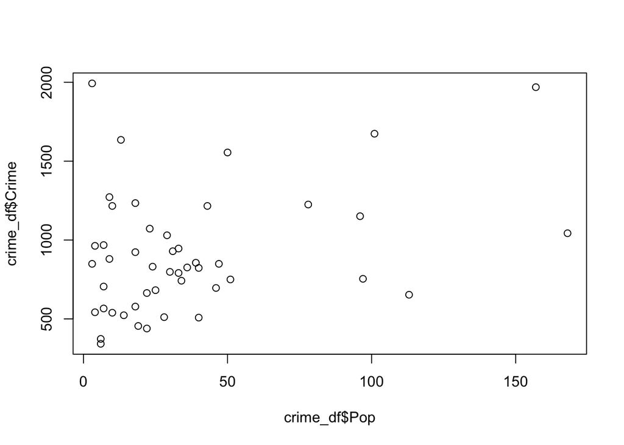

```r
#Plot crime by population
plot(x=crime_df$Pop,y=crime_df$Crime)
```

The two extreme large points seem like potentail outliers

### Outliers package

Grubbs’ test ([Grubbs 1969](https://www.itl.nist.gov/div898/handbook/eda/section4/eda43.htm#Grubbs) and [Stefansky 1972](https://www.itl.nist.gov/div898/handbook/eda/section4/eda43.htm#Stefansky)) is used to detect a single [outlier](https://www.itl.nist.gov/div898/handbook/eda/section3/eda35h.htm) in a univariate data set that follows an [approximately normal](https://www.itl.nist.gov/div898/handbook/eda/section3/eda35h.htm#Normality) distribution.

| H<sub>0</sub>: | There are no outliers in the data set |
| --- | --- |
| H<sub>a</sub>: | There is exactly one outlier in the data set |

The two salient assumptions here are:

1. Data is Normally Distributed
2. There is exactly one outlier

Before applying the test let us check for these two assumptions:

#### Assumption 1: Normality

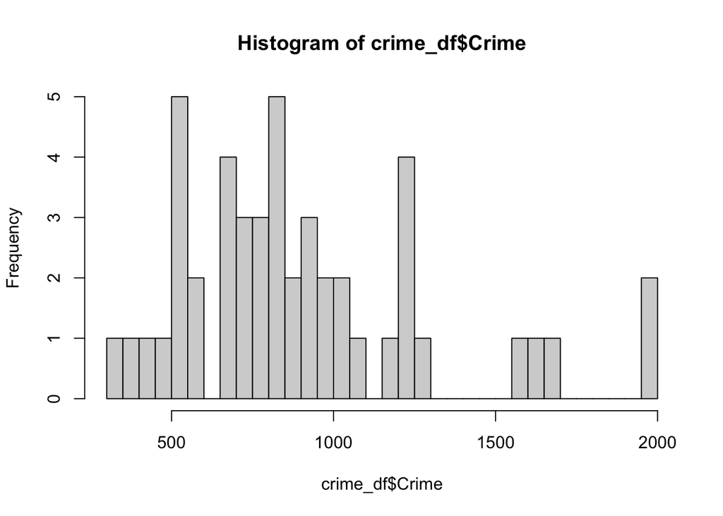

```r
hist(crime_df$Crime,breaks=25)
```

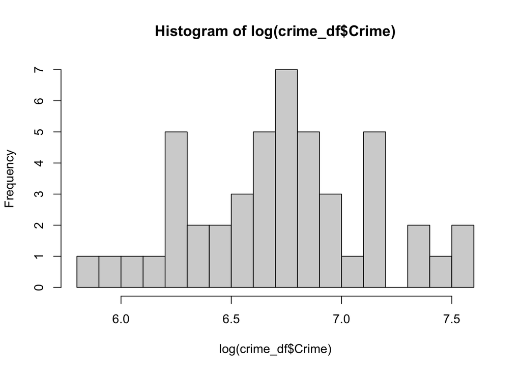

```r
hist(log(crime_df$Crime),breaks=20)
```

Basis Histogram the data presents deviation from normality as the distribution is not symmetric, especially without the log transformation. We can further test this with QQ plot

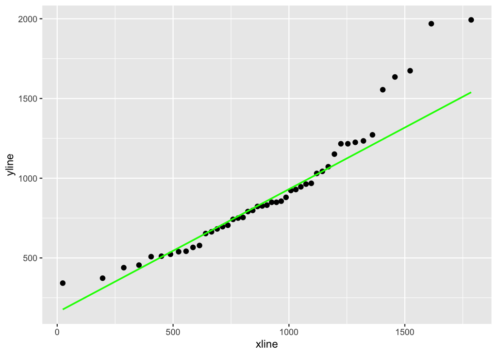

```r
ggplot(mapping = aes(sample = crime_df$Crime)) + stat_qq_point(size = 2) + stat_qq_line(color="green")
```

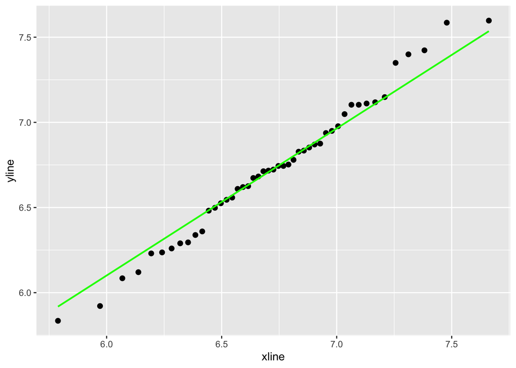

```r
ggplot(mapping = aes(sample = log(crime_df$Crime))) + stat_qq_point(size = 2) + stat_qq_line(color="green")
```

Similarly from QQ plot, we see that the points diverge from line especially at the extremes, hinting at non-normality in that region. While log of crime is relatively more normal, the log transformation alters the scale of data, and we might want to detect outliers before applying it.

**Since assumption 1 is not fully satisfied, we can not be 100% sure of the efficiency of Grubbs Test in our case.**

#### Assumption 2: Exactly one outlier

To check this assumption let us check the box plot of crime:

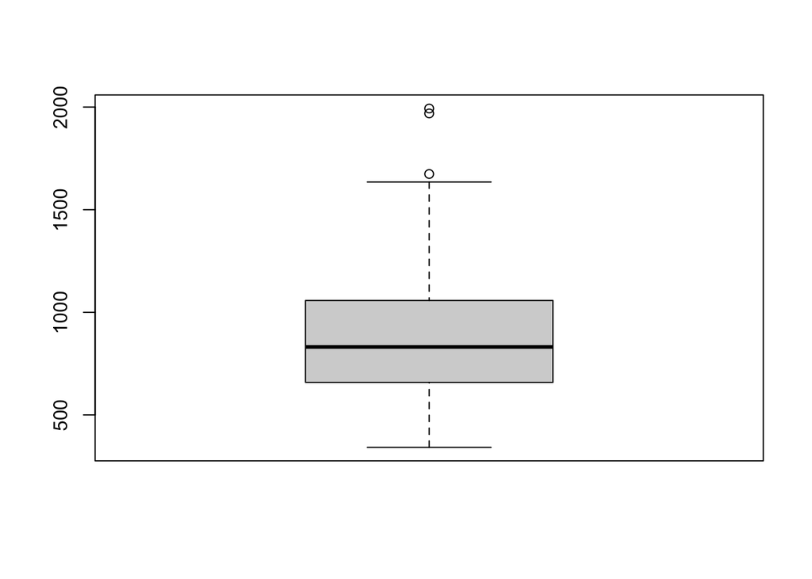

```r
boxplot(crime_df$Crime)
```

As seen in scatter plot, there are two points that seem pretty far away from the whiskers.

Let us further examine these two points:

```r
mask = crime_df$Crime > 1800
crime_df[mask,"Crime"]
```

```
## [1] 1969 1993
```

```r
crime_df[mask,]
```

|  | M | So | Ed | Po1 | Po2 | LF | M.F | Pop | NW | U1 | U2 | Wealth | Ineq | Prob | Time | Crime |
| --- | --- | --- | --- | --- | --- | --- | --- | --- | --- | --- | --- | --- | --- | --- | --- | --- |
| 4 | 13.6 | 0 | 12.1 | 14.9 | 14.1 | 0.577 | 99.4 | 157 | 8.0 | 0.102 | 3.9 | 6730 | 16.7 | 0.015801 | 29.9012 | 1969 |
| 26 | 13.1 | 0 | 12.1 | 16.0 | 14.3 | 0.631 | 107.1 | 3 | 7.7 | 0.102 | 4.1 | 6740 | 15.2 | 0.041698 | 22.1005 | 1993 |

We see that among these two points, there is disproportionate difference of population, $157 * 10^5$ vs $3 * 10^5$.

```r
paste(cor(crime_df$Pop,crime_df$Crime),cor(crime_df$Prob,crime_df$Crime))
```

```
## [1] "0.337474061306272 -0.427422188066401"
```

Basis population figures in 1960’s, there are two candidate states for 1993 point: Wyoming & Nevada.

And comparing data from [Disatster Center](https://www.disastercenter.com/crime/wycrime.htm), Wyoming does have roughly twice the national average crime rate, which is similar to our data as well (1993/ 905.1). Maybe there was some particular event in 1960 in Wyoming, which is causing such behavior. To understand this better, we need some expertise of Crime rate Trends in Wyoming.

**Hence this point maybe outlier but there is high likelihood that the underlying data is true, and the decision of dropping it would depend on our exact modelling needs.**

https://en.wikipedia.org/wiki/1960_United_States_census#:~:text=The%20United%20States%20census%20of,enumerated%20during%20the%201950%20census.

**Since assumption 2 is again not fully satisfied, we can not be 100% sure of the efficiency of Grubbs Test in our case.**

### Apply Grubbs Test

```r
grubbs.test(crime_df$Crime, type = 10, opposite = FALSE, two.sided = FALSE)
```

```
##
##  Grubbs test for one outlier
##
## data:  crime_df$Crime
## G = 2.81287, U = 0.82426, p-value = 0.07887
## alternative hypothesis: highest value 1993 is an outlier
```

As per Grubbs test, we get p-value of ~8%. $\implies$ there is 8% chance that the given point is the effect of randomness, assuming Null Hypothesis is True. Generally we want p-value to be as low as possible to reject the Null hypothesis.In this case 8% value is slightly larger than typical thresholds of 5%, and warrants detailed investigation before classifying the point as outlier, which is in sync with analysis above.

Let us also test what happens to the 2nd highest point, if the 1993 pt is removed

```r
mask1 = crime_df$Crime<1990
grubbs.test(crime_df[mask1,]$Crime, type = 10, opposite = FALSE, two.sided = FALSE)
```

```
##
##  Grubbs test for one outlier
##
## data:  crime_df[mask1, ]$Crime
## G = 3.06343, U = 0.78682, p-value = 0.02848
## alternative hypothesis: highest value 1969 is an outlier
```

After removing 1993 point we get even lower p-value this time, hinting that 1969 in absence of 1993 is a much stronger candidate for being a outlier.

Thus in conclusion, we have two candidate outliers in the data, 1993 and 1969 point. 1993 point is the highest crime rate and presents weak evidence to discard it as outlier, however, to be definitive, we need to study the Wyoming angle in detail, especially in relevance to exact modelling needs at hand.

## Question 8.1

### Example: Real Estate Price

Linear Regression models find use case in the real estate industry to predict selling price for a particular property depending on the prediction variables.

**Objective Function (Y)**: To predict the selling price of a property based in the predicting variables for that property

**Predicting Variables (X_i)**: Some of the key predicting variables are given below -

- *Location*: The location of the property is an important predictor for predicting the selling price. As properties in a good neighborhood will fetch higher prices than those in a relatively worse neighborhoods.
- *Lot Size*: Lot size is defined as the area of the property. A large lot size is worth more than a smaller lot.
- *Age of the House (Condition)*: Age of the house is the number of years since the construction of the house. It can also be considered as the condition metric of the house. A house with good condition grade can worth more than one with lower condition grade as it might incur lower maintenance cost.
- *Garage Capacity*: Capacity of garage is defines as the number of cars a garage can hold. The ability of the garage to hold more cars is an important factor which appreciates the value of a property

## Question 8.2

```r
crime_data<-read.table(file = "./uscrime.txt", sep = "\t",header=TRUE)
head(crime_data)
```

|  | M | So | Ed | Po1 | Po2 | LF | M.F | Pop | NW | U1 | U2 | Wealth | Ineq | Prob | Time | Crime |
| --- | --- | --- | --- | --- | --- | --- | --- | --- | --- | --- | --- | --- | --- | --- | --- | --- |
| 1 | 15.1 | 1 | 9.1 | 5.8 | 5.6 | 0.510 | 95.0 | 33 | 30.1 | 0.108 | 4.1 | 3940 | 26.1 | 0.084602 | 26.2011 | 791 |
| 2 | 14.3 | 0 | 11.3 | 10.3 | 9.5 | 0.583 | 101.2 | 13 | 10.2 | 0.096 | 3.6 | 5570 | 19.4 | 0.029599 | 25.2999 | 1635 |
| 3 | 14.2 | 1 | 8.9 | 4.5 | 4.4 | 0.533 | 96.9 | 18 | 21.9 | 0.094 | 3.3 | 3180 | 25.0 | 0.083401 | 24.3006 | 578 |
| 4 | 13.6 | 0 | 12.1 | 14.9 | 14.1 | 0.577 | 99.4 | 157 | 8.0 | 0.102 | 3.9 | 6730 | 16.7 | 0.015801 | 29.9012 | 1969 |
| 5 | 14.1 | 0 | 12.1 | 10.9 | 10.1 | 0.591 | 98.5 | 18 | 3.0 | 0.091 | 2.0 | 5780 | 17.4 | 0.041399 | 21.2998 | 1234 |
| 6 | 12.1 | 0 | 11.0 | 11.8 | 11.5 | 0.547 | 96.4 | 25 | 4.4 | 0.084 | 2.9 | 6890 | 12.6 | 0.034201 | 20.9995 | 682 |

```r
dim(crime_data)
```

```
## [1] 47 16
```

```r
summary(crime_data)
```

```
##        M               So               Ed             Po1
##  Min.   :11.90   Min.   :0.0000   Min.   : 8.70   Min.   : 4.50
##  1st Qu.:13.00   1st Qu.:0.0000   1st Qu.: 9.75   1st Qu.: 6.25
##  Median :13.60   Median :0.0000   Median :10.80   Median : 7.80
##  Mean   :13.86   Mean   :0.3404   Mean   :10.56   Mean   : 8.50
##  3rd Qu.:14.60   3rd Qu.:1.0000   3rd Qu.:11.45   3rd Qu.:10.45
##  Max.   :17.70   Max.   :1.0000   Max.   :12.20   Max.   :16.60
##       Po2               LF              M.F              Pop
##  Min.   : 4.100   Min.   :0.4800   Min.   : 93.40   Min.   :  3.00
##  1st Qu.: 5.850   1st Qu.:0.5305   1st Qu.: 96.45   1st Qu.: 10.00
##  Median : 7.300   Median :0.5600   Median : 97.70   Median : 25.00
##  Mean   : 8.023   Mean   :0.5612   Mean   : 98.30   Mean   : 36.62
##  3rd Qu.: 9.700   3rd Qu.:0.5930   3rd Qu.: 99.20   3rd Qu.: 41.50
##  Max.   :15.700   Max.   :0.6410   Max.   :107.10   Max.   :168.00
##        NW              U1                U2            Wealth
##  Min.   : 0.20   Min.   :0.07000   Min.   :2.000   Min.   :2880
##  1st Qu.: 2.40   1st Qu.:0.08050   1st Qu.:2.750   1st Qu.:4595
##  Median : 7.60   Median :0.09200   Median :3.400   Median :5370
##  Mean   :10.11   Mean   :0.09547   Mean   :3.398   Mean   :5254
##  3rd Qu.:13.25   3rd Qu.:0.10400   3rd Qu.:3.850   3rd Qu.:5915
##  Max.   :42.30   Max.   :0.14200   Max.   :5.800   Max.   :6890
##       Ineq            Prob              Time           Crime
##  Min.   :12.60   Min.   :0.00690   Min.   :12.20   Min.   : 342.0
##  1st Qu.:16.55   1st Qu.:0.03270   1st Qu.:21.60   1st Qu.: 658.5
##  Median :17.60   Median :0.04210   Median :25.80   Median : 831.0
##  Mean   :19.40   Mean   :0.04709   Mean   :26.60   Mean   : 905.1
##  3rd Qu.:22.75   3rd Qu.:0.05445   3rd Qu.:30.45   3rd Qu.:1057.5
##  Max.   :27.60   Max.   :0.11980   Max.   :44.00   Max.   :1993.0
```

### Data Distribution and Pairwise Corelation

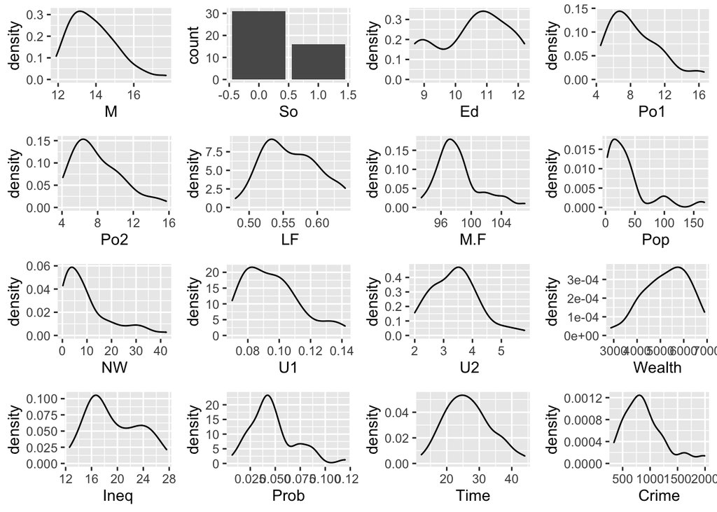

```r
my_plots <- lapply(names(crime_data), function(var_x){
  p <-
    ggplot(crime_data) +
    aes_string(var_x)

  if(var_x %in% list("So")) {
    p <- p + geom_bar()

  } else {
    p <- p + geom_density()
  }

})

plot_grid(plotlist = my_plots)
```

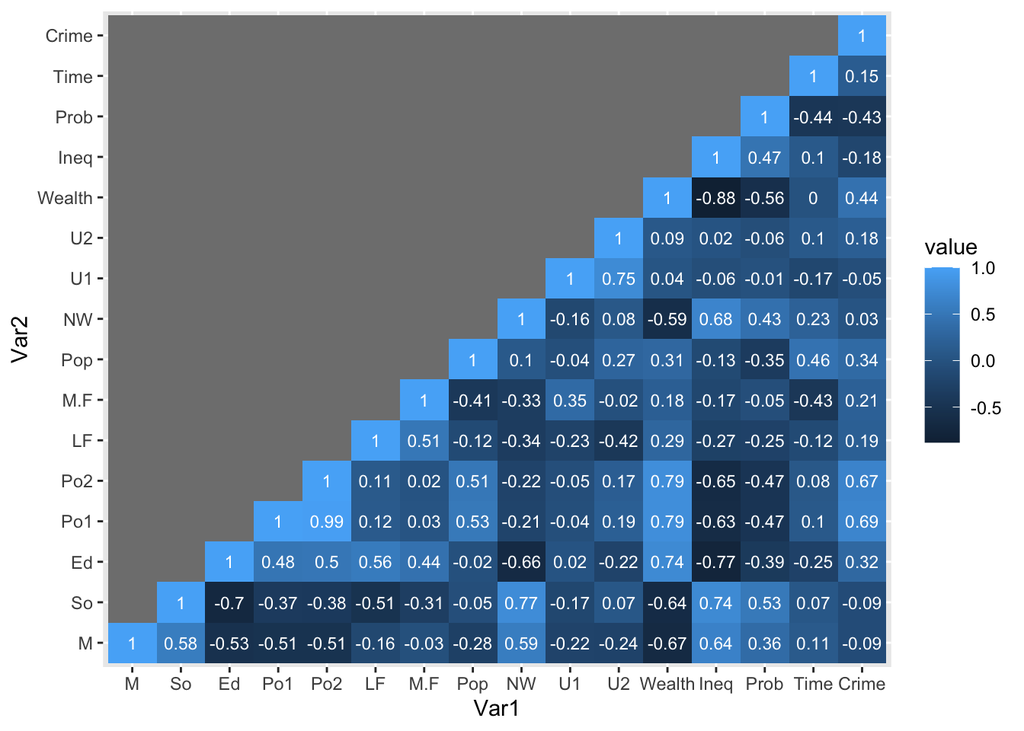

```r
### Correlation
cormat <- round(cor(crime_data),2)
cormat[upper.tri(cormat)] <- NA
melted_cormat <- melt(cormat)
# plotting the correlation heatmap

ggplot(data = melted_cormat, aes(x=Var1, y=Var2,
                                   fill=value)) +
geom_tile() +
geom_text(aes(Var1, Var2, label = value),
          color = "white", size = 3)
```

**#Analysis**

Wealth and Income Inequality are 2 highly correlated variables (-ve correlation), hence we can pick only 1 variable out of the 2. Po1 and Po2 are 2 highly correlated variables (+ve correlation), hence we can pick only 1 out of 2. Same goes for U1 and U2, hence we can pick only 1 out of 2

The dependent variable Crime Rate has high correlation with the following variables : Po1 and Po2 -> we see a surprising +ve correlation with crime rate. As regression cannot be used for defining a causal relation , we can infer the other way round that since the crime rate is higher, that could be the reason of a higher per capita expenditure on police protection.

Prob -> makes sense to have -ve correlation in this case. As the crime rate is bound to decrease if probability of imprisonment increases.

###Linearity in data between independent and dependent variables

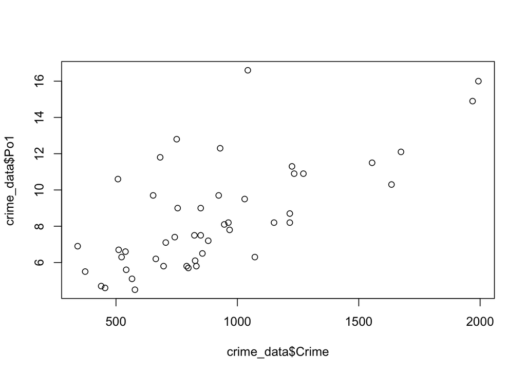

```r
plot(crime_data$Po1 ~ crime_data$Crime)
```

**#Analysis**

From the aove plot we can observe that there seems to be a linear relationship between the dependent variable and one of the highly correlated feature. Thus our assumption of linearity holds true and we can implement linear regression model.

###Initial Model

```r
options(scipen=999)
crime_data$So<-as.factor(crime_data$So)
# Linear Regression model with all features
lmodel_1<-lm(Crime~M+So+Ed+Po1+Po2+LF+M.F+Pop+NW+U1+U2+Wealth+Ineq+Prob+Time,data=crime_data)
summary(lmodel_1)
```

```
##
## Call:
## lm(formula = Crime ~ M + So + Ed + Po1 + Po2 + LF + M.F + Pop +
##     NW + U1 + U2 + Wealth + Ineq + Prob + Time, data = crime_data)
##
## Residuals:
##     Min      1Q  Median      3Q     Max
## -395.74  -98.09   -6.69  112.99  512.67
##
## Coefficients:
##                Estimate  Std. Error t value Pr(>|t|)
## (Intercept) -5984.28760  1628.31837  -3.675 0.000893 ***
## M              87.83017    41.71387   2.106 0.043443 *
## So1            -3.80345   148.75514  -0.026 0.979765
## Ed            188.32431    62.08838   3.033 0.004861 **
## Po1           192.80434   106.10968   1.817 0.078892 .
## Po2          -109.42193   117.47754  -0.931 0.358830
## LF           -663.82615  1469.72882  -0.452 0.654654
## M.F            17.40686    20.35384   0.855 0.398995
## Pop            -0.73301     1.28956  -0.568 0.573845
## NW              4.20446     6.48089   0.649 0.521279
## U1          -5827.10272  4210.28904  -1.384 0.176238
## U2            167.79967    82.33596   2.038 0.050161 .
## Wealth          0.09617     0.10367   0.928 0.360754
## Ineq           70.67210    22.71652   3.111 0.003983 **
## Prob        -4855.26582  2272.37462  -2.137 0.040627 *
## Time           -3.47902     7.16528  -0.486 0.630708
## ---
## Signif. codes:  0 '***' 0.001 '**' 0.01 '*' 0.05 '.' 0.1 ' ' 1
##
## Residual standard error: 209.1 on 31 degrees of freedom
## Multiple R-squared:  0.8031, Adjusted R-squared:  0.7078
## F-statistic: 8.429 on 15 and 31 DF,  p-value: 0.0000003539
```

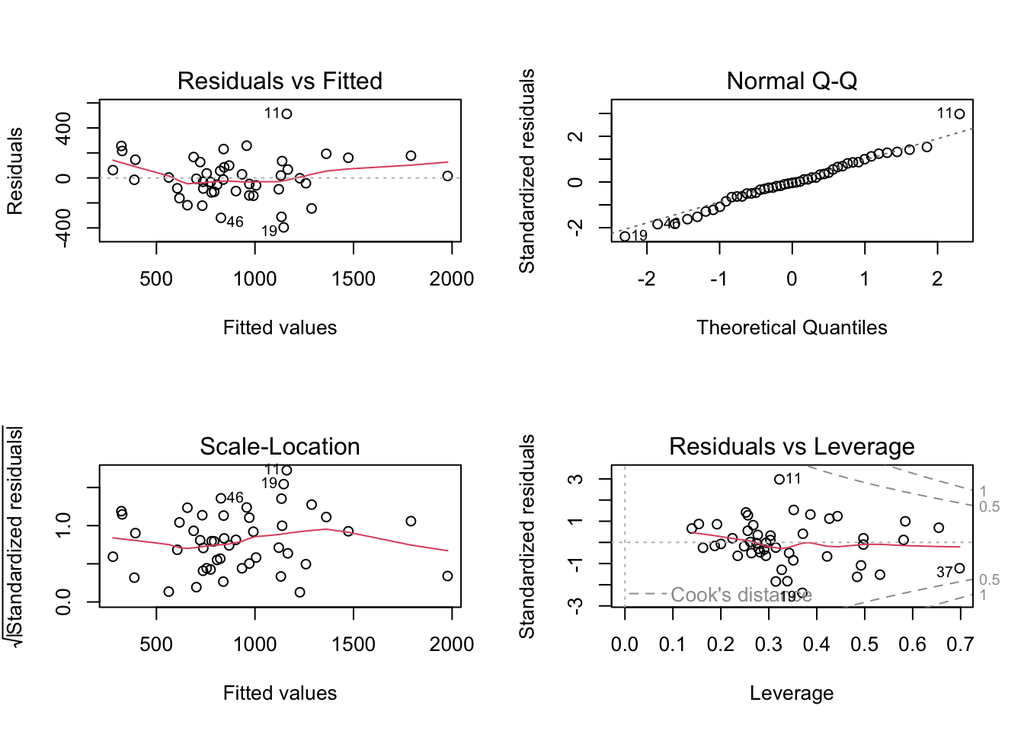

```r
# plotting the residuals to check for assumptions in the plain vanilla model with all features
par(mfrow = c(2, 2))
plot(lmodel_1)
```

```r
new_datapoint<-data.frame(M=c(14.0),So=c(as.factor(0)),Ed=c(10.0),Po1=c(12.0),Po2=c(15.5),LF=c(0.640),M.F=c(94.0),Pop=c(150),NW=c(1.1),U1=c(0.120),U2=c(3.6),Wealth=c(3200),Ineq=c(20.1),Prob=c(0.04),Time=c(39.0))
crime_rate_pred<-predict(lmodel_1,newdata = new_datapoint)
crime_rate_pred<-round(crime_rate_pred,2)
print(paste("Predicted Value:", crime_rate_pred))
```

```
## [1] "Predicted Value: 155.43"
```

**#Analysis**

- For this model, the $R^{2}$ value is 0.8 which means that 80% of the variance in the dependent variable is explained by the set of these independent variables .
- The predicted crime_rate for the given data point is 155.43. Since this prediction lies outside the range of or dependent variable, we can further tune the model as the features of the predicting data point lie withing the domain of independent variables.
- From the 4 diagnostic plots associated with the linear regression model, we can see that the assumptions are mostly in place, error terms are normally distributed i.e. constant variance assumption and residuals are homogeneous around the fitted line. However , we can see slight bends in the left and right end in the plot of residuals vs fitted values. Thus, a possible remedy can be thought of as transforming the dependent variable (taking a log transformation reduces the range of possible variables).
- Further from the QQ Plot it can be inferred that the data is normally distributed. Thus our normality assumption also holds true.

**Points for further exploration** : * Taking a log transformation of the dependent variable and then create a regression model. * Create a model with lower number of features (remove highly correlated features). * Look for possible outliers/leverage points (based on the residuals vs leverage plot - cook’s distance) and remove them to see changes in the model output.

###Taking log transformation of the dependent variable with all features

```r
# Taking log transformation of the dependent variable with all features
options(scipen=999)
crime_data$So<-as.factor(crime_data$So)
# Linear Regression model with all features
lmodel_2<-lm(log(Crime)~M+So+Ed+Po1+Po2+LF+M.F+Pop+NW+U1+U2+Wealth+Ineq+Prob+Time,data=crime_data)
summary(lmodel_2)
```

```
##
## Call:
## lm(formula = log(Crime) ~ M + So + Ed + Po1 + Po2 + LF + M.F +
##     Pop + NW + U1 + U2 + Wealth + Ineq + Prob + Time, data = crime_data)
##
## Residuals:
##      Min       1Q   Median       3Q      Max
## -0.41697 -0.10961  0.01903  0.10971  0.47322
##
## Coefficients:
##               Estimate Std. Error t value Pr(>|t|)
## (Intercept)  0.4345908  1.7884057   0.243  0.80960
## M            0.1160700  0.0458149   2.533  0.01657 *
## So1          0.0917576  0.1633799   0.562  0.57841
## Ed           0.2147289  0.0681926   3.149  0.00361 **
## Po1          0.1862712  0.1165418   1.598  0.12012
## Po2         -0.1077276  0.1290273  -0.835  0.41015
## LF           0.1874034  1.6142245   0.116  0.90833
## M.F         -0.0061943  0.0223549  -0.277  0.78355
## Pop         -0.0009638  0.0014163  -0.681  0.50124
## NW           0.0047976  0.0071181   0.674  0.50530
## U1          -4.3033459  4.6242214  -0.931  0.35925
## U2           0.1717980  0.0904308   1.900  0.06680 .
## Wealth       0.0001737  0.0001139   1.526  0.13715
## Ineq         0.0808730  0.0249499   3.241  0.00284 **
## Prob        -6.0950555  2.4957820  -2.442  0.02050 *
## Time        -0.0080381  0.0078697  -1.021  0.31497
## ---
## Signif. codes:  0 '***' 0.001 '**' 0.01 '*' 0.05 '.' 0.1 ' ' 1
##
## Residual standard error: 0.2296 on 31 degrees of freedom
## Multiple R-squared:  0.7897, Adjusted R-squared:  0.688
## F-statistic: 7.761 on 15 and 31 DF,  p-value: 0.0000008862
```

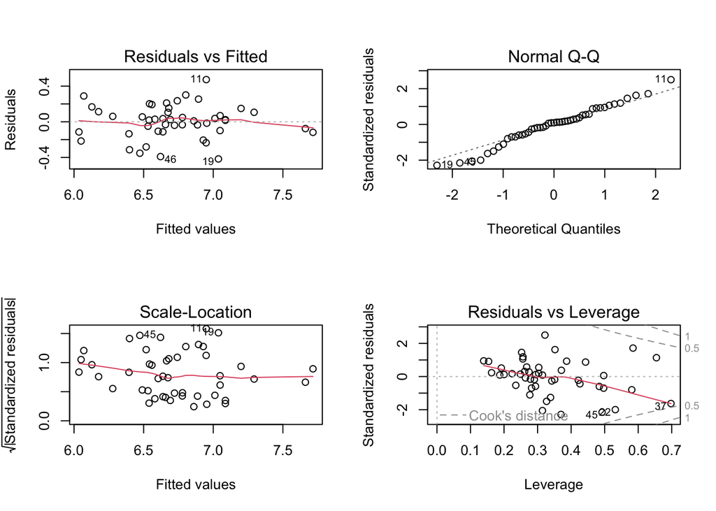

```r
# plotting the residuals to check for assumptions in the plain vanilla model with all features
par(mfrow = c(2, 2))
plot(lmodel_2)
```

```r
crime_rate_pred<-predict(lmodel_2,newdata = new_datapoint)
crime_rate_pred<- exp(crime_rate_pred)
print(paste("Predicted Value:", round(crime_rate_pred,2)))
```

```
## [1] "Predicted Value: 363.96"
```

**#Analysis**

Again, the predicted crime_rate for the given data point is 363.9568311. The value has gotten within the range of dependent variable. But we can still work on our model.

###Taking log transformation of the dependent variable with selected features

```r
# Taking log transformation of the dependent variable with selected features
options(scipen=999)
crime_data$So<-as.factor(crime_data$So)
# Linear Regression model with reduced # of features
lmodel_3<-lm(log(Crime)~M+So+Ed+Po1+LF+M.F+Pop+NW+U1+Ineq+Prob+Time,data=crime_data)
summary(lmodel_3)
```

```
##
## Call:
## lm(formula = log(Crime) ~ M + So + Ed + Po1 + LF + M.F + Pop +
##     NW + U1 + Ineq + Prob + Time, data = crime_data)
##
## Residuals:
##      Min       1Q   Median       3Q      Max
## -0.44190 -0.11680  0.03509  0.12732  0.53639
##
## Coefficients:
##               Estimate Std. Error t value   Pr(>|t|)
## (Intercept)  1.7050974  1.7115208   0.996    0.32617
## M            0.0871515  0.0471300   1.849    0.07314 .
## So1          0.2493683  0.1629077   1.531    0.13509
## Ed           0.1770090  0.0672289   2.633    0.01264 *
## Po1          0.1274870  0.0236611   5.388 0.00000538 ***
## LF           1.1124389  1.6340780   0.681    0.50062
## M.F         -0.0097146  0.0233567  -0.416    0.68008
## Pop         -0.0009004  0.0015019  -0.599    0.55282
## NW           0.0001822  0.0071061   0.026    0.97970
## U1           3.2311713  3.0755522   1.051    0.30085
## Ineq         0.0607452  0.0210938   2.880    0.00684 **
## Prob        -6.0919242  2.5425828  -2.396    0.02223 *
## Time        -0.0024262  0.0077366  -0.314    0.75574
## ---
## Signif. codes:  0 '***' 0.001 '**' 0.01 '*' 0.05 '.' 0.1 ' ' 1
##
## Residual standard error: 0.2448 on 34 degrees of freedom
## Multiple R-squared:  0.7379, Adjusted R-squared:  0.6454
## F-statistic: 7.978 on 12 and 34 DF,  p-value: 0.0000008274
```

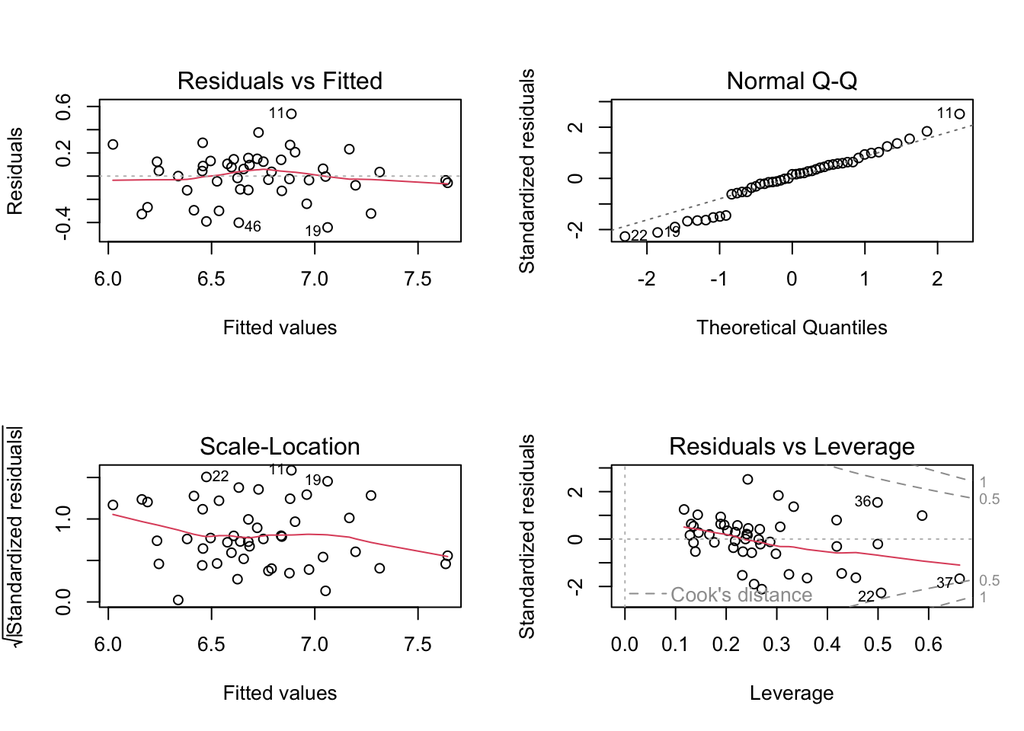

```r
# plotting the residuals to check for assumptions in the plain vanilla model with all features
par(mfrow = c(2, 2))
plot(lmodel_3)
```

```r
crime_rate_pred<-predict(lmodel_3,newdata = new_datapoint)
crime_rate_pred<- exp(crime_rate_pred)
print(paste("Predicted Value:", round(crime_rate_pred,2)))
```

```
## [1] "Predicted Value: 1286.27"
```

**#Analysis**

- We can see that by removing a few predicting features, the value of $R_{2}$ has gotten worse. We are not able to explain much on the basis of our predicting feature.
- We also observe that our predicted value for the new data point has gotten closer to the mean response.
- Another thing to observe is the P-value for one feature (“Po1”) has gotten significantly small and we can reject the null hypothesis. Thus it is a significant predictor for our model.

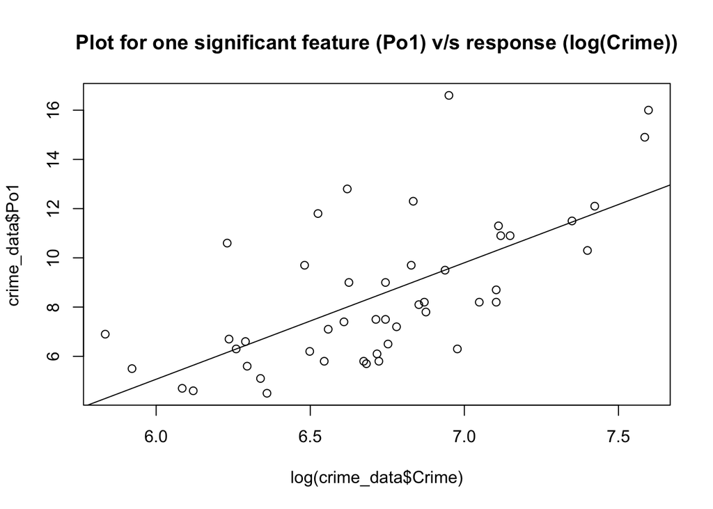

```r
plot(crime_data$Po1 ~ log(crime_data$Crime), main="Plot for one significant feature (Po1) v/s response (log(Crime))")
abline(lm(crime_data$Po1 ~ log(crime_data$Crime)))
```

```r
# removing the potential outliers/influential points based on the diagnostic plots of linear regression model
crime_data_wo<-crime_data[-c(11, 19, 46),]

# Taking log transformation of the dependent variable with all features
options(scipen=999)
crime_data$So<-as.factor(crime_data$So)
# Linear Regression model with reduced # of features and removed potential influential points.
lmodel_4<-lm(log(Crime)~M+So+Ed+Po1+LF+M.F+Pop+NW+U1+Ineq+Prob+Time,data=crime_data)
summary(lmodel_4)
```

```
##
## Call:
## lm(formula = log(Crime) ~ M + So + Ed + Po1 + LF + M.F + Pop +
##     NW + U1 + Ineq + Prob + Time, data = crime_data)
##
## Residuals:
##      Min       1Q   Median       3Q      Max
## -0.44190 -0.11680  0.03509  0.12732  0.53639
##
## Coefficients:
##               Estimate Std. Error t value   Pr(>|t|)
## (Intercept)  1.7050974  1.7115208   0.996    0.32617
## M            0.0871515  0.0471300   1.849    0.07314 .
## So1          0.2493683  0.1629077   1.531    0.13509
## Ed           0.1770090  0.0672289   2.633    0.01264 *
## Po1          0.1274870  0.0236611   5.388 0.00000538 ***
## LF           1.1124389  1.6340780   0.681    0.50062
## M.F         -0.0097146  0.0233567  -0.416    0.68008
## Pop         -0.0009004  0.0015019  -0.599    0.55282
## NW           0.0001822  0.0071061   0.026    0.97970
## U1           3.2311713  3.0755522   1.051    0.30085
## Ineq         0.0607452  0.0210938   2.880    0.00684 **
## Prob        -6.0919242  2.5425828  -2.396    0.02223 *
## Time        -0.0024262  0.0077366  -0.314    0.75574
## ---
## Signif. codes:  0 '***' 0.001 '**' 0.01 '*' 0.05 '.' 0.1 ' ' 1
##
## Residual standard error: 0.2448 on 34 degrees of freedom
## Multiple R-squared:  0.7379, Adjusted R-squared:  0.6454
## F-statistic: 7.978 on 12 and 34 DF,  p-value: 0.0000008274
```

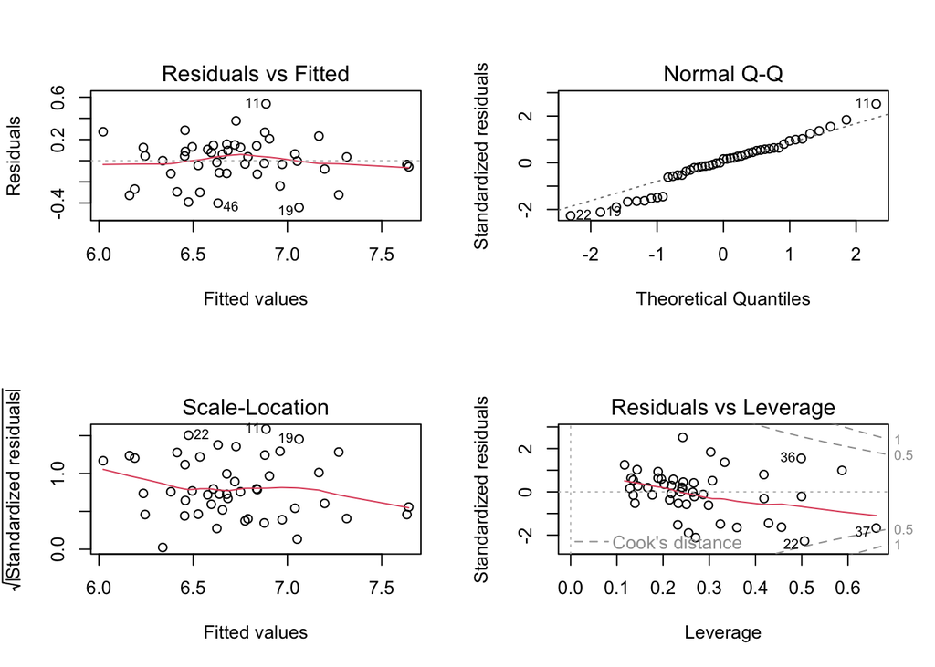

```r
# plotting the residuals to check for assumptions in the plain vanilla model with all features
par(mfrow = c(2, 2))
plot(lmodel_4)
```

```r
crime_rate_pred<-predict(lmodel_4,newdata = new_datapoint)
crime_rate_pred<- exp(crime_rate_pred)
print(paste("Predicted Value:", round(crime_rate_pred,2)))
```

```
## [1] "Predicted Value: 1286.27"
```

**#Analysis**